# Anvio

```r
library(tidyverse)
library(ggtext)
library(viridis)
library(RColorBrewer)
library(knitr)
library(ggh4x)
library(reshape2)
library(seqinr)
```

## Set up paths

```r
#This will open the .Renviron file for the project. You need to add a DATA_PATH environment variable with the path to your data folder.
#usethis::edit_r_environ(scope = "project")

# This will create and open the .bash_env file for editing. You need to add a DATA_PATH environment variable with the path to your data folder.
#file.create(".bash_env")
#file.edit(".bash_env")

FOLDER_PATH <- Sys.getenv("DATA_PATH")
genomes_list_folder <- file.path(FOLDER_PATH, "genome_lists")
anvio_folder <- file.path(FOLDER_PATH, "anvio-9")
```

This notebook contains analyses using anvi’o version 9 (Delmont and Eren, 2018; Eren et al., 2020). For more in-depth information about anvi’o go to their official online site here: https://anvio.org/

We first source the `.bash_env` file to set up the environment variables.

```bash
source .bash_env
```

## Functional annotations

We use as input (`path_i`) the anvi’o contigs database files (`.db`) that were generated in Methods_Prokka_Annotations.

### COG annotation

First we downloaded and set up the NCBI’s Clusters of Orthologous Groups databaseGalperin et al. (2024) using `anvi-setup-ncbi-cogs`. The default is the latest version, which is COG24, meaning that anvi’o will use the NCBI’s 2024 release of COGs to setup the database.

The `anvi-run-ncbi-cogs` command was used to annotate the contig databases. We used DIAMOND as searching method(Buchfink et al., 2014) with the recommended “sensitive” option.

```bash
conda deactivate
conda activate anvio-9

path_i="$DATA_PATH/anvio-9/contigs_db"

for file in $path_i/*.db; do
    anvi-run-ncbi-cogs -T 8 --search-with diamond -c $file;
done
```

### KEGG annotation

First we downloaded and set up the KEGG KOfam(Kanehisa, 2000; Kanehisa et al., 2022) database using `anvi-setup-kegg-data`. We used the snapshot of the KEGG database dated 2025-11-07 (hash 68221bd12b3).

The program `anvi-run-kegg-kofams` annotates genes in a given anvi’o contigs database with KEGG Orthology (KO) numbers via hits to the KEGG KOfam database (Aramaki et al., 2019). We used `-E` lower than 1e-15.

```bash
conda deactivate
conda activate anvio-9

path_i="$DATA_PATH/anvio-9/contigs_db"

for file in $path_i/*.db; do
    anvi-run-kegg-kofams -T 8 --log-bitscores -E 1e-15 --just-do-it -c $file;
done
```

The option `--log-bitscores` records the bit scores values. They get saved to the main folder for the repo, so we moved them to a new subfolder.

```r
path_i <- "."
path_o <- file.path(anvio_folder, "KEGG_bitscores")
dir.create(path_o, recursive = TRUE, showWarnings = FALSE)
files_to_move <- list.files(path_i, pattern = "_bitscores.txt$", full.names = TRUE)

for (file in files_to_move) {
  new_path <- file.path(path_o, basename(file))
  print(new_path)
  file.rename(file, new_path)
}
```

### PFAM annotation

First you need to download and set up the PFAM database(Bateman, 2000; Mistry et al., 2020) using `anvi-setup-pfams`: this is something you will do only once. We used Pfam version 38.1 (2025-09)

```bash
conda deactivate
conda activate anvio-9

path_i="$DATA_PATH/anvio-9/contigs_db"

for file in $path_i/*.db; do
    anvi-run-pfams -T 8 -c $file;
done
```

### CAZyme Annotation

First you need to download and set up the CAZyme database (Drula et al., 2021) using `anvi-setup-cazymes`: this is something you will do only once. We used CAZyme version 12.

The program `anvi-run-cazymes` annotates genes in your contigs-db with the dbCAN CAZyme database.

```bash
conda deactivate
conda activate anvio-9

path_i="$DATA_PATH/anvio-9/contigs_db"

for file in $path_i/*.db; do
    anvi-run-cazymes -T 8 -c $file;
done
```

### Getting HMMs

When you run the `anvi-run-hmms` command the occurrence of bacterial single-copy genes across your contigs is added to your contigs database (Eddy, 2011).

```bash
conda deactivate
conda activate anvio-9

path_i="$DATA_PATH/anvio-9/contigs_db"

for file in $path_i/*.db; do
    anvi-run-hmms -T 8 -c $file --just-do-it;
done
```

### Getting Metabolic Networks

The program `anvi-reaction-network` is used to store a metabolic reaction-network in each contigs-db. The network consists of data on biochemical reactions predicted to be encoded by each genome, referencing the KEGG Orthology (KO) and ModelSEED Biochemistry databases.

```bash
conda deactivate
conda activate anvio-9

path_i="$DATA_PATH/anvio-9/contigs_db"

for file in $path_i/*.db; do
    anvi-reaction-network -c $file;
done
```

### Annotation Summaries

This generates basic stats on the annotations:

```bash
conda deactivate
conda activate anvio-9

path_i="$DATA_PATH/anvio-9/contigs_db"
path_o="$DATA_PATH/anvio-9/annotation_summaries"
mkdir -p "$path_o"

for file in $path_i/*.db; do
    FILENAME=`basename ${file%.*}`
    anvi-display-contigs-stats $file --report-as-text -o $path_o/stats_$FILENAME.txt;
done
```

This provides basic info on the contigs databases:

```bash
conda deactivate
conda activate anvio-9

path_i="$DATA_PATH/anvio-9/contigs_db"
path_o="$DATA_PATH/anvio-9/annotation_summaries"

for file in $path_i/*.db; do
    anvi-db-info $file &>> $path_o/anvi-db-info_log.txt;
done
```

## Metabolic Analysis

### Estimation of KEGG module completeness

Using `anvi-estimate-metabolism` we predicted KEGG module completeness as described in (Veseli et al., 2023) for the the organisms listed in `anvio_KEGG_30_CtuComplex.txt`. This list includes the name of the 30 *Corynebacterium* genomes selected for metabolic analysis and the path to the corresponding anvi’o .db files.

```bash
conda deactivate
conda activate anvio-9

txt_file="$DATA_PATH/genome_lists/anvio_KEGG_30_CtuComplex.txt"
prefix=NovCor
path_o="$DATA_PATH/anvio-9/metabolic_analysis"
mkdir -p "$path_o"

anvi-estimate-metabolism -e $txt_file \
                         -O $path_o/$prefix --add-copy-number --output-modes hits,modules
```

The generated `NovCor_modules.txt` is included as **Table S4** in the manuscript. It contains the KEGG module completeness values for each genome, which are used to generate the KEGG module summary **Table S5**, and the heatmap in **Figure 4**.

#### Code for KEGG Manuscript Table S5

```r
# Read modules data and make appropriate labeling columns
Modules <- read_delim(file.path(anvio_folder, "metabolic_analysis/NovCor_modules.txt"), show_col_types = FALSE, col_types = cols(unique_enzymes_hit_counts = col_character(), gene_caller_ids_in_module = col_character())) %>%
  mutate(module_class_short = paste0("(", substr(module_class, 1, 1), ")")) %>%
  unite(modules_label, c(module_class_short, module_category, module_subcategory), sep = "_", remove = FALSE) %>%
  mutate_at(c("genome_name", "module", "module_name", "module_category", "module_subcategory", "modules_label"), factor)

# Summary tally table of fully stepwise complete modules by species. Filter to modules present in at least 20 genomes
ModulesTable <- Modules %>%
  filter(stepwise_module_completeness == 1) %>%
  group_by(module_class, module_category, module_subcategory, module, module_name) %>%
  tally() %>%
  ungroup() %>%
  select(module, module_name, module_subcategory, n, -module_class) %>%
  arrange(desc(n)) %>%
  filter(n > 20)

write_csv(ModulesTable, file.path(anvio_folder, "metabolic_analysis/NovCor_KEEG_Table.csv"))
kable(ModulesTable)
```

| module | module_name | module_subcategory | n |
| --- | --- | --- | --- |
| M00015 | Proline biosynthesis, glutamate => proline | Arginine and proline metabolism | 30 |
| M00844 | Arginine biosynthesis, ornithine => arginine | Arginine and proline metabolism | 30 |
| M00970 | Proline degradation, proline => glutamate | Arginine and proline metabolism | 30 |
| M00022 | Shikimate pathway, phosphoenolpyruvate + erythrose-4P => chorismate | Aromatic amino acid metabolism | 30 |
| M00019 | Valine/isoleucine biosynthesis, pyruvate => valine / 2-oxobutanoate => isoleucine | Branched-chain amino acid metabolism | 30 |
| M00432 | Leucine biosynthesis, 2-oxoisovalerate => 2-oxoisocaproate | Branched-chain amino acid metabolism | 30 |
| M00570 | Isoleucine biosynthesis, threonine => 2-oxobutanoate => isoleucine | Branched-chain amino acid metabolism | 30 |
| M00021 | Cysteine biosynthesis, serine => cysteine | Cysteine and methionine metabolism | 30 |
| M00045 | Histidine degradation, histidine => N-formiminoglutamate => glutamate | Histidine metabolism | 30 |
| M00018 | Threonine biosynthesis, aspartate => homoserine => threonine | Serine and threonine metabolism | 30 |
| M00020 | Serine biosynthesis, glycerate-3P => serine | Serine and threonine metabolism | 30 |
| M00621 | Glycine cleavage system | Serine and threonine metabolism | 30 |
| M00096 | C5 isoprenoid biosynthesis, non-mevalonate pathway | Terpenoid backbone biosynthesis | 30 |
| M00364 | C10-C20 isoprenoid biosynthesis, bacteria | Terpenoid backbone biosynthesis | 30 |
| M00365 | C10-C20 isoprenoid biosynthesis, archaea | Terpenoid backbone biosynthesis | 30 |
| M00097 | Lycopene biosynthesis, geranylgeranyl-PP => lycopene | Terpenoid biosynthesis | 30 |
| M00001 | Glycolysis (Embden-Meyerhof pathway), glucose => pyruvate | Central carbohydrate metabolism | 30 |
| M00002 | Glycolysis, core module involving three-carbon compounds | Central carbohydrate metabolism | 30 |
| M00003 | Gluconeogenesis, oxaloacetate => fructose-6P | Central carbohydrate metabolism | 30 |
| M00004 | Pentose phosphate pathway (Pentose phosphate cycle) | Central carbohydrate metabolism | 30 |
| M00005 | PRPP biosynthesis, ribose 5P => PRPP | Central carbohydrate metabolism | 30 |
| M00006 | Pentose phosphate pathway, oxidative phase, glucose 6P => ribulose 5P | Central carbohydrate metabolism | 30 |
| M00007 | Pentose phosphate pathway, non-oxidative phase, fructose 6P => ribose 5P | Central carbohydrate metabolism | 30 |
| M00009 | Citrate cycle (TCA cycle, Krebs cycle) | Central carbohydrate metabolism | 30 |
| M00010 | Citrate cycle, first carbon oxidation, oxaloacetate => 2-oxoglutarate | Central carbohydrate metabolism | 30 |
| M00011 | Citrate cycle, second carbon oxidation, 2-oxoglutarate => oxaloacetate | Central carbohydrate metabolism | 30 |
| M00632 | Galactose degradation, Leloir pathway, galactose => alpha-D-glucose-1P | Other carbohydrate metabolism | 30 |
| M00855 | Glycogen degradation, glycogen => glucose-6P | Other carbohydrate metabolism | 30 |
| M00151 | Cytochrome bc1 complex respiratory unit | ATP synthesis | 30 |
| M00155 | Cytochrome c oxidase, prokaryotes | ATP synthesis | 30 |
| M00157 | F-type ATPase, prokaryotes and chloroplasts | ATP synthesis | 30 |
| M00579 | Phosphate acetyltransferase-acetate kinase pathway, acetyl-CoA => acetate | Carbon fixation | 30 |
| M00549 | UDP-Glc biosynthesis, Glc => UDP-Glc | Nucleotide sugar biosynthesis | 30 |
| M00554 | UDP-Gal biosynthesis, Gal => UDP-Gal | Nucleotide sugar biosynthesis | 30 |
| M00793 | dTDP-L-Rha biosynthesis, Glc-1P => dTDP-L-Rha | Nucleotide sugar biosynthesis | 30 |
| M00909 | UDP-GlcNAc biosynthesis, prokaryotes, Fru-6P => UDP-GlcNAc | Nucleotide sugar biosynthesis | 30 |
| M00995 | UDP-MurNAc biosynthesis, Fru-6P => UDP-MurNAc | Nucleotide sugar biosynthesis | 30 |
| M01004 | UDP-Galf biosynthesis, UDP-Glc => UDP-Galf | Nucleotide sugar biosynthesis | 30 |
| M00888 | Galactofuranan biosynthesis, decaprenyl phosphate + UDP-GlcNAc (+ dTDP-Rha/UDP-Galf) => GL-5 | Other polysaccharide metabolism | 30 |
| M00086 | beta-Oxidation, acyl-CoA synthesis | Fatty acid metabolism | 30 |
| M00887 | Mycolic acid biosynthesis, meromycolic acid + alpha-carboxyacyl-CoA + trehalose => TMM => TDM/mAGP/GMM | Fatty acid metabolism | 30 |
| M00120 | Coenzyme A biosynthesis, pantothenate => CoA | Cofactor and vitamin metabolism | 30 |
| M00121 | Heme biosynthesis, plants and bacteria, glutamate => heme | Cofactor and vitamin metabolism | 30 |
| M00125 | Riboflavin biosynthesis, plants and bacteria, GTP => riboflavin/FMN/FAD | Cofactor and vitamin metabolism | 30 |
| M00126 | Tetrahydrofolate biosynthesis, GTP => THF | Cofactor and vitamin metabolism | 30 |
| M00881 | Lipoic acid biosynthesis, plants and bacteria, octanoyl-ACP => dihydrolipoyl-E2/H | Cofactor and vitamin metabolism | 30 |
| M00899 | Thiamine salvage pathway, HMP/HET => TMP | Cofactor and vitamin metabolism | 30 |
| M00916 | Pyridoxal-P biosynthesis, R5P + glyceraldehyde-3P + glutamine => pyridoxal-P | Cofactor and vitamin metabolism | 30 |
| M00926 | Heme biosynthesis, bacteria, glutamyl-tRNA => coproporphyrin III => heme | Cofactor and vitamin metabolism | 30 |
| M00048 | De novo purine biosynthesis, PRPP + glutamine => IMP | Purine metabolism | 30 |
| M00049 | Adenine ribonucleotide biosynthesis, IMP => ADP,ATP | Purine metabolism | 30 |
| M00050 | Guanine ribonucleotide biosynthesis, IMP => GDP,GTP | Purine metabolism | 30 |
| M00053 | Deoxyribonucleotide biosynthesis, ADP/GDP/CDP/UDP => dATP/dGTP/dCTP/dUTP | Purine metabolism | 30 |
| M00938 | Pyrimidine deoxyribonucleotide biosynthesis, UDP => dTTP | Pyrimidine metabolism | 30 |
| M00023 | Tryptophan biosynthesis, chorismate => tryptophan | Aromatic amino acid metabolism | 29 |
| M00555 | Betaine biosynthesis, choline => betaine | Serine and threonine metabolism | 29 |
| M00140 | C1-unit interconversion, prokaryotes | Cofactor and vitamin metabolism | 29 |
| M00028 | Ornithine biosynthesis, glutamate => ornithine | Arginine and proline metabolism | 26 |
| M00016 | Lysine biosynthesis, succinyl-DAP pathway, aspartate => lysine | Lysine metabolism | 26 |
| M00017 | Methionine biosynthesis, aspartate => homoserine => methionine | Cysteine and methionine metabolism | 25 |
| M00307 | Pyruvate oxidation, pyruvate => acetyl-CoA | Central carbohydrate metabolism | 25 |
| M01014 | UDP-ManNAcA biosynthesis, UDP-GlcNAc => UDP-ManNAcA | Nucleotide sugar biosynthesis | 25 |
| M00982 | Methylcitrate cycle | Other carbohydrate metabolism | 24 |

#### Code for KEGG Manuscript Figure 4

```r
# When using stepwise_module_completeness some modules can be = 0 for all genomes but still have pathwise_module_completeness > 0. We are removing those modules.
Modules_cleaned <- Modules %>%
  group_by(module) %>%
  filter(!all(stepwise_module_completeness == 0)) %>%
  ungroup() %>%
  mutate(across(where(is.factor), droplevels))

all_zero_modules <- setdiff(Modules$module, Modules_cleaned$module)
all_zero_subcategory <- setdiff(Modules$module_subcategory, Modules_cleaned$module_subcategory)

# Calculating mean_stepwise_module_completeness and preparing plot labels
Modules_Means = Modules_cleaned %>%
  group_by(modules_label, genome_name, .drop = FALSE) %>%
  summarise(mean_stepwise_module_completeness = mean(stepwise_module_completeness)) %>%
  mutate(mean_stepwise_module_completeness = coalesce(mean_stepwise_module_completeness, 0)) %>%
  mutate(species_name = str_extract(genome_name, "^[^_]+")) %>%
  mutate(module_category = str_extract(modules_label, "^[^_]+_[^_]+")) %>%
  mutate(module_category = str_replace_all(module_category, "_", " ")) %>%
  mutate(modules_final_label = str_replace(modules_label, "^[^_]+_[^_]+_", "")) %>%
  mutate_at(c("module_category", "modules_final_label"), factor)

# Reorder based on ANI results and add styled genome names for plotting
StrainOrder <- read_csv(file.path(genomes_list_folder, "ANI_PlotOrder_30_CtuComplex_styled.csv"))
Modules_Means <- left_join(Modules_Means, StrainOrder, by = c("genome_name" = "Genome"))

Modules_Means$species_name <- sub("Cke", "Cna", Modules_Means$species_name)
Modules_Means$species_name <- sub("Cau", "Cmq", Modules_Means$species_name)
Modules_Means$species_name <- factor(Modules_Means$species_name, levels = c("Cna","Cyo","Cmq","Ctu","Ccu","Cha"))
Modules_Means$genome_name <- factor(Modules_Means$genome_name, levels = StrainOrder$Genome)
Modules_Means$styled_Genome <- factor(Modules_Means$styled_Genome, levels = rev(StrainOrder$styled_Genome))
Modules_Means$modules_final_label  <- factor(Modules_Means$modules_final_label, rev(levels(Modules_Means$modules_final_label)))
```

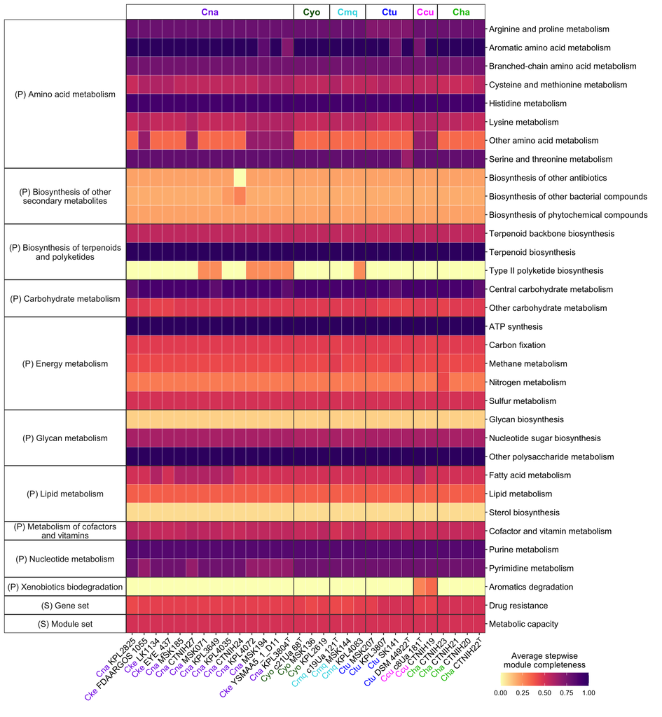

```r
# Colors for plot
colorsSpecies <- c("#8200E7","#0A6003","#39D9E5","#002BFF","#FF00FF","#0ABF00")

# Heatmap plot
plot <- ggplot(Modules_Means, aes(x = styled_Genome, y = modules_final_label, fill = mean_stepwise_module_completeness)) +
  geom_tile(color = "white") +
  facet_grid2(module_category ~ species_name, scales = "free", space = "free", switch = "y", labeller = label_wrap_gen(width = 31),
              #strip = strip_themed(background_x = elem_list_rect(fill = colorsSpecies))) +
              strip = strip_themed(text_x = elem_list_text(colour = colorsSpecies))) +
  labs(x = "", y = "") +
  scale_y_discrete(expand = c(0,0), position = "right") +
  scale_x_discrete(expand = c(0,0)) +
  scale_fill_viridis(direction = -1, option = "A", begin = 0.2) +
  theme_bw() +
  theme(panel.grid.major = element_blank(),
        panel.grid.minor = element_blank(),
        strip.background = element_rect(colour = "black", fill = NA),
        strip.text.y.left = element_text(angle = 0, hjust = 0.5, size = 11),
        strip.text.x = element_text(size = 12, face = "bold"),
        axis.text.y = element_text(size = 11, color = "black"),
        axis.text.x = element_markdown(angle = 45, hjust = 1, size = 11, color = "black"),
        panel.spacing = unit(0, 'pt'),
        legend.position = c(1.30, -0.11),
        legend.direction = "horizontal",
        legend.justification = c(1, 0)) +
  guides(fill = guide_colourbar(title = "Average stepwise\nmodule completeness", title.position = "top", title.hjust = 0.5, barwidth = 8))


ggsave(plot = plot, filename = file.path(anvio_folder, "metabolic_analysis/NovCor_KEEG_Figure.png"), height = 13, width = 12, device = 'png', dpi = 600)
saveRDS(plot, file = file.path(anvio_folder, "metabolic_analysis/NovCor_KEEG_Figure.rds"))
plot
```

### Module Enrichment Analysis

The `NovCor_modules.txt` file generated in the previous step is used by `anvi-compute-metabolic-enrichment` to calculate KEGG module enrichment(Shaiber et al., 2020) across different groups of genomes. We used the `-G` flag to indicate the following grouping options:

- Enriched KEGG modules in *Corynebacterium nasorum* versus other *Corynebacterium tuberculostearicum* species complex genomes.
- Enriched KEGG modules in *Corynebacterium hallucis* versus other *Corynebacterium tuberculostearicum* species complex genomes.

```bash
conda deactivate
conda activate anvio-9

csv_file_modules="$DATA_PATH/anvio-9/metabolic_analysis/NovCor_modules.txt"
path_o="$DATA_PATH/anvio-9/metabolic_analysis/enrichment_modules"
mkdir -p "$path_o"

txt_file_groups="$DATA_PATH/genome_lists/anvio_MetabolicEnrichment_Groups_Cna.txt"
output_file="$path_o/NovCor_enriched_modules_stepwise_1_Cna.txt"
anvi-compute-metabolic-enrichment -M "$csv_file_modules" \
                                  -G "$txt_file_groups" \
                                  -o "$output_file" \
                                  --use-stepwise-completeness \
                                  --module-completion-threshold 1.0

txt_file_groups="$DATA_PATH/genome_lists/anvio_MetabolicEnrichment_Groups_Cha.txt"
output_file="$path_o/NovCor_enriched_modules_stepwise_1_Cha.txt"
anvi-compute-metabolic-enrichment -M "$csv_file_modules" \
                                  -G "$txt_file_groups" \
                                  -o "$output_file" \
                                  --use-stepwise-completeness \
                                  --module-completion-threshold 1.0
```

### KO Enrichment Analysis

We use `anvi-display-functions`(Shaiber et al., 2020). It runs the enrichment for the desired annotations (in this case KOfam). It saves the output to a temp file that can be recovered, renamed and saved into the same `path_o` as the database file.

- **Table S6.** Enriched KOs in *Corynebacterium nasorum* versus other *Corynebacterium tuberculostearicum* species complex genomes.
- **Table S7.** Enriched KOs in *Corynebacterium hallucis* versus other *Corynebacterium tuberculostearicum* species complex genomes.

```bash
conda deactivate
conda activate anvio-9

txt_file="$DATA_PATH/genome_lists/anvio_KEGG_30_CtuComplex.txt"
path_o="$DATA_PATH/anvio-9/metabolic_analysis/enrichment_KOs"
mkdir -p "$path_o"

txt_file_groups="$DATA_PATH/genome_lists/anvio_MetabolicEnrichment_Groups_Cna.txt"
anvi-display-functions -e $txt_file \
                       --groups-txt $txt_file_groups \
                       --annotation-source KOfam \
                       --profile-db $path_o/KOfam_Cna.db

txt_file_groups="$DATA_PATH/genome_lists/anvio_MetabolicEnrichment_Groups_Cha.txt"
anvi-display-functions -e $txt_file \
                       --groups-txt $txt_file_groups \
                       --annotation-source KOfam \
                       --profile-db $path_o/KOfam_Cha.db
```

### Reading results into R

This allows to read the generated enrichment results for KEGG modules and KOs into R for further analysis and plotting.

```r
Enrich_Mod_Cna <- read_delim(file.path(anvio_folder, "metabolic_analysis/enrichment_modules/NovCor_enriched_modules_stepwise_1_Cna.txt"), show_col_types = FALSE)
Enrich_Mod_Cha <- read_delim(file.path(anvio_folder, "metabolic_analysis/enrichment_modules/NovCor_enriched_modules_stepwise_1_Cna.txt"), show_col_types = FALSE)

Enrich_KO_Cna <- read_delim(file.path(anvio_folder, "metabolic_analysis/enrichment_KOs/NovCor_enriched_KOs_Cna.txt"), show_col_types = FALSE)
Enrich_KO_Cha <- read_delim(file.path(anvio_folder, "metabolic_analysis/enrichment_KOs/NovCor_enriched_KOs_Cha.txt"), show_col_types = FALSE)
```

## Pangenomic level analysis

This analysis using `anvio_KEGG_30_CtuComplex.txt` includes the same 30 *Corynebacterium* genomes selected for metabolic analysis.

```bash
conda deactivate
conda activate anvio-9

txt_file="$DATA_PATH/genome_lists/anvio_KEGG_30_CtuComplex.txt"
path_i="$DATA_PATH/anvio-9/pangenomic_analysis"
mkdir -p "$path_i"

anvi-gen-genomes-storage -e $txt_file -o $path_i/NovCor-GENOMES.db --gene-caller Prodigal

anvi-db-info $path_i/NovCor-GENOMES.db

anvi-pan-genome -g $path_i/NovCor-GENOMES.db \
                -o $path_i/pangenome -n NovCor \
                --use-ncbi-blast --mcl-inflation 10  --num-threads 8

#Create a bin collection named CORE with all Core GCs for all the included genomes using the visual interface:

anvi-display-pan -p $path_i/pangenome/NovCor-PAN.db -g $path_i/NovCor-GENOMES.db

anvi-summarize -p $path_i/pangenome/NovCor-PAN.db \
               -g $path_i/NovCor-GENOMES.db \
               -o $path_i/summaries \
               -C CORE
```

### Reading results into R

The `NovCor_gene_clusters_summary.txt.gz` file contains the summary of gene clusters generated in the pangenomic analysis, which can be used to explore specific gene clusters of interest based on the enrichment results.

```r
NovCor_PAN <- read_delim(file.path(anvio_folder, "pangenomic_analysis/summaries/NovCor_gene_clusters_summary.txt.gz"), show_col_types = FALSE)
```

This function allows to explored the generated summary dataset for any GC of interest. It generates a subset of the dataset, a fasta file with the protein alignment and a identity percent distance matrix foe any selected GC:

```r
info_for_GC <- function(Summary, output_path, GC, gene) {
  data <- Summary %>%
    filter(gene_cluster_id == GC) %>%
    mutate(fasta_lines = paste0(">", gene_cluster_id, "|", genome_name, "|callers_id:", gene_callers_id, "\n", aa_sequence))

  if (!file.exists(output_path)) {
    dir.create(output_path, recursive = TRUE)
  }
  output_fasta <- file.path(output_path, paste0(GC, "_", gene, ".fasta"))
  output_csv <- file.path(output_path, paste0(GC, "_", gene, ".csv"))

  writeLines(data$fasta_lines, con = output_fasta)
  write_csv(data, file = output_csv)

  dist = dist.alignment(read.alignment(output_fasta,"fasta"), matrix = "identity")
  mat <- 100*(1 - dist^2) # convert to identity percent since the dist matrix contains the squared root of the pairwise distances
  mat <- as.matrix(mat)
  df <- melt(mat)
  df$value <- as.numeric(df$value)
  df$Var1 <- sub(".*\\|(.*?)\\|.*", "\\1", df$Var1)
  df$Var2 <- sub(".*\\|(.*?)\\|.*", "\\1", df$Var2)

  if (nrow(df) > 1) {
    plot <- ggplot(df, aes(x = Var1, y = Var2, fill = value)) +
      geom_tile() +
      scale_fill_viridis(direction = -1, option = "A", begin = 0.2, limits = c(40, 100), na.value = 'white') +
      labs(x = "", y = "") +
      scale_y_discrete(expand = c(0,0), position = "right") +
      scale_x_discrete(expand = c(0,0)) +
      theme_bw() +
      theme(axis.text.x = element_markdown(angle = 45, hjust = 1, size = 6),
            axis.text.y = element_markdown(size = 6))

    output_plot <- file.path(output_path, paste0(GC, "_", gene, ".jpg"))
    ggsave(plot, filename = output_plot, height = 20, width = 20, device = 'jpg', dpi = 600)
  }

  num_seqs <- nrow(data)
  num_genomes <- data$num_genomes_gene_cluster_has_hits[1]
  protein_id <- ifelse("Cgl_ATCC_13032" %in% data$genome_name, data$accession[data$genome_name == "Cgl_ATCC_13032"][1], NA)
  KO <- ifelse("Cgl_ATCC_13032" %in% data$genome_name, data$KOfam_ACC[data$genome_name == "Cgl_ATCC_13032"][1], NA)
  index <- data$combined_homogeneity_index[1]

  cat(protein_id, gene, GC, KO, "has", num_seqs, "aa sequences across", num_genomes, "genomes with", index ,"combined homogeneity. \n")
}
```

```r
output_path <- file.path(anvio_folder, "pangenomic_analysis/individual_GCs")

info_for_GC(NovCor_PAN, output_path, "GC_00002114", "YncB")
```

```
NA YncB GC_00002114 NA has 16 aa sequences across 16 genomes with 0.9477969 combined homogeneity.
```

```r
info_for_GC(NovCor_PAN, output_path, "GC_00002607", "nagB")
```

```
NA nagB GC_00002607 NA has 4 aa sequences across 4 genomes with 0.9976981 combined homogeneity.
```

**Aramaki, T., Blanc-Mathieu, R., Endo, H., Ohkubo, K., Kanehisa, M., Goto, S. and Ogata, H.** (2019). [KofamKOALA: KEGG Ortholog assignment based on profile HMM and adaptive score threshold](https://doi.org/10.1093/bioinformatics/btz859). *Bioinformatics* 36, 2251–2252.

**Bateman, A.** (2000). [The pfam protein families database](https://doi.org/10.1093/nar/28.1.263). *Nucleic Acids Research* 28, 263–266.

**Buchfink, B., Xie, C. and Huson, D. H.** (2014). [Fast and sensitive protein alignment using DIAMOND](https://doi.org/10.1038/nmeth.3176). *Nature Methods* 12, 59–60.

**Delmont, T. O. and Eren, A. M.** (2018). [Linking pangenomes and metagenomes: the *Prochlorococcus* metapangenome](https://doi.org/10.7717/peerj.4320). *PeerJ* 6, e4320.

**Drula, E., Garron, M.-L., Dogan, S., Lombard, V., Henrissat, B. and Terrapon, N.** (2021). [The carbohydrate-active enzyme database: functions and literature](https://doi.org/10.1093/nar/gkab1045). *Nucleic Acids Research* 50, D571–D577.

**Eddy, S. R.** (2011). [Accelerated Profile HMM Searches](https://doi.org/10.1371/journal.pcbi.1002195). *PLoS Computational Biology* 7, e1002195.

**Eren, A. M., Kiefl, E., Shaiber, A., Veseli, I., Miller, S. E., Schechter, M. S., Fink, I., Pan, J. N., Yousef, M., Fogarty, E. C., et al.** (2020). [Community-led, integrated, reproducible multi-omics with anvi’o](https://doi.org/10.1038/s41564-020-00834-3). *Nature Microbiology* 6, 3–6.

**Galperin, M. Y., Wolf, Y. I., Makarova, K. S., Vera Alvarez, R., Landsman, D. and Koonin, E. V.** (2020). [COG database update: focus on microbial diversity, model organisms, and widespread pathogens](https://doi.org/10.1093/nar/gkaa1018). *Nucleic Acids Research* 49, D274–D281.

**Galperin, M. Y., Vera Alvarez, R., Karamycheva, S., Makarova, K. S., Wolf, Y., Landsman, D. and Koonin, E. V.** (2024). [COG database update 2024](https://doi.org/10.1093/nar/gkae983). *Nucleic Acids Research* 53, D356–D363.

**Kanehisa, M.** (2000). [KEGG: Kyoto encyclopedia of genes and genomes](https://doi.org/10.1093/nar/28.1.27). *Nucleic Acids Research* 28, 27–30.

**Kanehisa, M., Furumichi, M., Sato, Y., Kawashima, M. and Ishiguro-Watanabe, M.** (2022). [KEGG for taxonomy-based analysis of pathways and genomes](https://doi.org/10.1093/nar/gkac963). *Nucleic Acids Research* 51, D587–D592.

**Mistry, J., Chuguransky, S., Williams, L., Qureshi, M., Salazar, G., Sonnhammer, E. L. L., Tosatto, S. C. E., Paladin, L., Raj, S., Richardson, L. J., et al.** (2020). [Pfam: The protein families database in 2021](https://doi.org/10.1093/nar/gkaa913). *Nucleic Acids Research* 49, D412–D419.

**Shaiber, A., Willis, A. D., Delmont, T. O., Roux, S., Chen, L.-X., Schmid, A. C., Yousef, M., Watson, A. R., Lolans, K., Esen, Ö. C., et al.** (2020). [Functional and genetic markers of niche partitioning among enigmatic members of the human oral microbiome](https://doi.org/10.1186/s13059-020-02195-w). *Genome Biology* 21,.

**Tatusov, R. L.** (2000). [The COG database: A tool for genome-scale analysis of protein functions and evolution](https://doi.org/10.1093/nar/28.1.33). *Nucleic Acids Research* 28, 33–36.

**Veseli, I., Chen, Y. T., Schechter, M. S., Vanni, C., Fogarty, E. C., Watson, A. R., Jabri, B., Blekhman, R., Willis, A. D., Yu, M. K., et al.** (2023). [Microbes with higher metabolic independence are enriched in human gut microbiomes under stress](http://dx.doi.org/10.1101/2023.05.10.540289). *biorxiv*.